# Commercial Vehicle PD model

Nilabja Ray

### Variable Description

#### 1. ApplicationID, AGREEMENT_NO

- **Type:** Numeric/Alphanumeric string
- **Description:** Primary identifier for individual data-points.

```r
print(dat[,uniqueN(ApplicationID),])
```

```
[1] 17301
```

```r
print(dat[,uniqueN(AGREEMENT_NO),])
```

```
[1] 17301
```

#### 2. final_cif_no

- **Type:** Numeric String
- **Description:** Primary identifier for Customers.

```r
print(dat[,uniqueN(final_cif_no),])
```

```
[1] 11581
```

```r
dat[,.(acc_count=uniqueN(ApplicationID)),by=final_cif_no][order(-acc_count)]
```

```
       final_cif_no acc_count
    1:    101032005        75
    2:      1369188        62
    3:       236732        54
    4:      1391226        50
    5:        18701        44
   ---
11577:      1593140         1
11578:      1595412         1
11579:      1593964         1
11580:      1573203         1
11581:      1471716         1
```

#### 3. Location

- **Type:** String
- **Description:** City/Town name

```r
dat[,.(acc_count=uniqueN(ApplicationID)),by=Location][order(-acc_count)]
```

```
          Location acc_count
 1:          Delhi      3380
 2:         Mumbai      2040
 3:           Pune      1133
 4:         Jaipur      1119
 5:         Meerut       946
 6:        Chennai       730
 7:    BHUBANESWAR       686
 8:      Bangalore       631
 9:        Jodhpur       618
10:         INDORE       470
11:        Bargarh       454
12:           Bhuj       444
13:      Hyderabad       337
14:          Noida       290
```

[output cut: 73 more lines]

#### 4. state

- **Type:** String
- **Description:** Name of state where loan was disbursed

```r
dat[,.(acc_count=uniqueN(ApplicationID)),by=state][order(-acc_count)]
```

```
             state acc_count
 1:    Delhi - NCR      3670
 2:    Maharashtra      3656
 3:      Rajasthan      2392
 4:         Orissa      1350
 5:  Uttar Pradesh      1292
 6:      Tamilnadu      1047
 7:        Gujarat       999
 8: Madhya Pradesh       694
 9:      Karnataka       674
10:        HARYANA       508
11:      Telangana       357
12:    CHATTISHGAR       266
13:    Uttarakhand       168
14: Andhra Pradesh       103
15:     Chandigarh        80
16:         PUNJAB        43
17:            Goa         2
```

#### 5. CV_Old_New_flag

- **Type:** Bool
- **Description:** Whether new or resell vehicle. Only New vehicle data to be used.

```r
unique(dat[,CV_Old_New_flag])
```

```
[1] ""    "New"
```

```r
dat[CV_Old_New_flag=='',CV_Old_New_flag:='Old']
dat=dat[CV_Old_New_flag=='New']
```

#### 6. Product

- **Type:** Factor
- **Description:** Types of Loan Product. 4 different levels.

```r
dat[,.(account_count=uniqueN(ApplicationID)),by=Product]
```

```
                                Product account_count
1:                   COMMERCIAL VEHICLE         13245
2:             COMMERCIAL VEHICLE - AIB          2096
3: COMMERCIAL VEHICLE - Trailer Funding          1492
4:  COMMERCIAL VEHICLE - Sand Operators             4
```

#### 7. Loan_purpose

- **Type:** Factor
- **Description:** Purpose of the loan. 10 levels

```r
dat[,.(acc_count=uniqueN(ApplicationID)),by=Loan_purpose][order(-acc_count)]
```

```
                  Loan_purpose acc_count
 1:       New Vehicle Purchase      6636
 2:                                 4160
 3:      Used Vehicle Purchase      1757
 4:                 NEW_CHASIS      1490
 5: Refinance Existing Vehicle      1046
 6:                   NEW_BODY       552
 7:               USED_VEHICLE       399
 8:          REFINANCE_VEHICLE       357
 9:    NEW_FULLY_BUILT_VEHICLE       287
10: New Vehicle Purchase -Body       153
```

#### 8. PROMOTIONDESC

- **Type:** Factor
- **Description:** Description of the loan-taker.

```r
unique(dat[,PROMOTIONDESC])
```

```
 [1] "FIRST TIME BUYER"
 [2] "TRANSPORTER C CATEGORY"
 [3] "TRANSPORTER A CATEGORY"
 [4] "CAPTIVE D CATEGORY"
 [5] "TRANSPORTER B CATEGORY"
 [6] "FIRST TIME USER"
 [7] "Bus Operator - Retail Small Operators"
 [8] "TRANSPORTER D CATEGORY"
 [9] "Bus Operator - Strategic"
[10] "TRANSPORTER"
[11] "Bus Operator - Retail"
[12] "AIB Small Commercial Vehicles 2"
[13] "FARMERS"
[14] "Captive B"
[15] "AIB FTU (first time user)"
```

[output cut: 48 more lines]

#### 9. CONSTITUTION

- **Type:** Factor
- **Description:** Type of the customer (Indiv, HUF, Proprietor, pvt ltd etc). Total 12 levels.

```r
dat[,uniqueN(ApplicationID),by=CONSTITUTION]
```

```
                     CONSTITUTION    V1
 1:                    Individual 14878
 2:                    Proprietor   823
 3:            Private Limited Co   583
 4:                       Society    40
 5:              Partnership Firm   363
 6:                         Trust    77
 7:                        Others    23
 8:        Co-Operative Societies     3
 9:             Public Limited Co    11
10:                                  23
11: Limited Liability Partnership    12
12:                           HUF     1
```

#### 10. DISBDT

- **Type:** Date
- **Description:** Date of disbursal of the loan. DISBDT is unique for each account.

```r
dat[,DISBDT:=as.Date(DISBDT,format='%d-%m-%Y')]
```

##### Yearly distribution of disbursal

```r
dat[,.(account_count=uniqueN(ApplicationID)), by=year(DISBDT)][order(year)]
```

```
   year account_count
1: 2012           172
2: 2013           768
3: 2014          1727
4: 2015          2537
5: 2016          3522
6: 2017          5941
7: 2018          2170
```

#### 11. due_date

- **Type:** Date
- **Description:** Date when the next EMI is due

```r
dat[due_date=='',due_date:=NA]
dat[,due_date:=as.Date(due_date,format='%d-%m-%Y')]
```

#### 12. DISB_AMT

- **Type:** Numeric
- **Description:** Amount Disbursed.

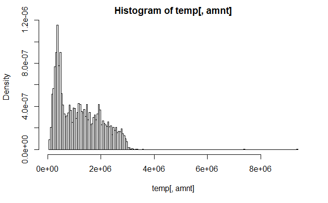

```r
dat[,DISB_AMT:=as.numeric(DISB_AMT)]
temp = dat[,.(amnt=mean(DISB_AMT)),by=ApplicationID]
hist(temp[,amnt],breaks=200,freq = FALSE)
```

#### 13. roi

- **Type:** Numeric
- **Description:** Rate of interest. For accounts with fixed rate, this will be constant. For Float roi accounts, roi is diff for every month.

```r
dat[,roi:=as.numeric(roi)]
summary(dat[,roi])
```

```
   Min. 1st Qu.  Median    Mean 3rd Qu.    Max.
   0.00   11.71   12.72   13.16   14.51   22.06
```

#### 14. MANUFACTURERDESC

- **Type:** String
- **Description:** Name of Vehicle Manufacturer

```r
dat[,.(acc_count=uniqueN(ApplicationID)),by=MANUFACTURERDESC][order(-acc_count)]
```

```
                      MANUFACTURERDESC acc_count
 1:                    TATA MOTORS LTD      9526
 2:                  ASHOK LEYLAND LTD      3967
 3:         VE COMMERCIAL VEHICLES LTD      1093
 4:               PRIVATE BODY BUILDER       660
 5:              MAHINDRA AND MAHINDRA       625
 6:                      ASHOK LEYLAND       394
 7:                        BHARAT BENZ       172
 8:                       FORCE MOTORS       136
 9:                       SWARAJ MAZDA       106
10:                  EICHER MOTORS LTD        77
11:                             EICHER        36
12: DAIMLER INDIA COMMERCIAL V PVT LTD         8
13:                           MAHINDRA         7
14:       VOLVO CONSTRUCTION EQUIPMENT         6
15:      SREE VENKATESHWARA INDUSTRIES         5
16:                             MARUTI         5
17:                             TOYOTA         5
18:     JAY BAJRANG MOTOR BODY REPAIRS         3
19:               ASIA MOTOR WORKS LTD         3
20:                               TATA         3
```

#### 15. CATGDESC

```r
dat[,.(acc_count=uniqueN(ApplicationID)),by=CATGDESC][order(-acc_count)]
```

```
    CATGDESC acc_count
 1:      HCV      7397
 2:    M&HCV      3402
 3:      SCV      2580
 4:      LCV      2046
 5:      BUS       699
 6:      MCV       380
 7:     BODY       249
 8:       TT        74
 9:  TIPPERS         8
10: STANDARD         1
11:      MUV         1
```

#### 16. ASSETCOST

- **Type:** Numeric
- **Description:** Cost of the Vehicle.

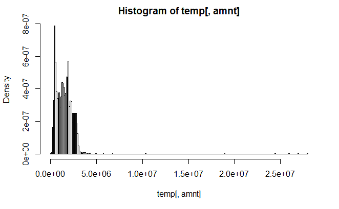

```r
dat[,ASSETCOST:=as.numeric(ASSETCOST)]
temp = dat[,.(amnt=mean(ASSETCOST)),by=ApplicationID]
hist(temp[,amnt],breaks=200,freq = FALSE)
```

#### 17. asset_level

- **Type:** Factor
- **Description:** Classified in three levels based on the Price, make n model of the vehicle. Contains missing observations.

```r
dat[,.(acc_count=uniqueN(ApplicationID)),asset_level][order(-acc_count)]
```

```
   asset_level acc_count
1:     Level 1     16160
2:     Level 2       381
3:                   188
4:     Level 3       108
```

#### 18. woff_flag

- **Type:** Bool
- **Description:** Whether part of the loan was written off or not.

```r
dat[,woff_flag:=woff_flag=='1']
dat[,.(acc_count=uniqueN(ApplicationID)),by=woff_flag]
```

```
   woff_flag acc_count
1:     FALSE     16792
2:      TRUE        45
```

#### 19. POS

- **Type:** Numeric
- **Description:** Principal OutStanding. Part of the principal that is still unpaid.

```r
dat[,POS:=as.numeric(POS)]
```

#### 20. DPD_Days

- **Type:** Integer
- **Description:** Days Past Delinquency

```r
dat[,DPD_Days:=as.integer(DPD_Days)]
dat[,.(acc_count=uniqueN(ApplicationID)),by=DPD_Days][order(DPD_Days)]
```

```
     DPD_Days acc_count
  1:        0     16421
  2:        7       949
  3:       11       119
  4:       17       894
  5:       27      1667
 ---
212:     1487         4
213:     1500         1
214:     1517         3
215:     1530         1
216:       NA      3051
```

#### 21. NPA_since_date

```r
dat[NPA_since_date=='',NPA_since_date:=NA]
dat[,NPA_since_date:=as.Date(NPA_since_date,format='%d-%m-%Y')]
```

#### 22. Asof

- **Type:** Date
- **Description:** Snapshot date

```r
dat[,Asof:=as.Date(Asof,format='%d-%m-%Y')]
```

#### 23. Bounces

- **Type:** Bool
- **Description:** Flag whether any of the customers cheque/SI have bounced or not

```r
dat[,Bounces:=Bounces!='']
```

#### 24. closed_status

- **Type:**
- **Description:**

```r
dat[,.(acc_count = uniqueN(ApplicationID)),by=closed_status]
```

```
   closed_status acc_count
1:             C      3049
2:                   16781
```

```r
dat[,closed_status:=closed_status=='C']
```

#### 25. Restructure_status

- **Type:**
- **Description:**

```r
dat[,Restructure_status:=Restructure_status=='Restructure']
```

#### 26. dq

- **Type:** Factor
- **Description:** Levels of Delinquincy

```r
unique(dat[,dq])
```

```
[1] ""    "4.5" "3"   "0"   "1"   "5"   "2"   "4"
```

#### 27. ever_x, ever_30, ever_60

- **Type:** Bool
- **Description:** Whether the account has ever been to dq_x, dq_30 and dq_60 ever.

```r
dat[,ever_x:=ever_x=='1']
dat[,ever_30:=ever_30=='1']
dat[,ever_60:=ever_60=='1']
```

#### 28. total_bounces

- **Type:** Integer
- **Description:** Total Number of times a cheque/SI has bounced

```r
dat[,total_bounces:=as.integer(total_bounces)]
summary(dat[,total_bounces])
```

```
   Min. 1st Qu.  Median    Mean 3rd Qu.    Max.
  0.000   0.000   0.000   2.824   3.000  52.000
```

#### 29. nonstarter, Quick_Mortality_Flag

- **Type:** Bool
- **Description:**

```r
dat[,nonstarter:=nonstarter=="1"]
dat[,Quick_Mortality_Flag:=Quick_Mortality_Flag!=""]
dat[,.(acc_count=uniqueN(ApplicationID)),nonstarter]
```

```
   nonstarter acc_count
1:      FALSE     16837
2:       TRUE       263
```

```r
dat[,.(acc_count=uniqueN(ApplicationID)),Quick_Mortality_Flag]
```

```
   Quick_Mortality_Flag acc_count
1:                FALSE     16796
2:                 TRUE       186
```

#### 30. Presentations

- **Type:** Bool
- **Description:** Whether a cheque was presented or not.

```r
dat[,Presentations:=Presentations=='1']
```

#### Valiable Selection

```r
a=c("ApplicationID",
    "AGREEMENT_NO",
"final_cif_no",
"Location",
"state",
"CV_Old_New_flag",
"Product",
"Loan_purpose",
"PROMOTIONDESC",
"CONSTITUTION",
"DISBDT",
"due_date",
"DISB_AMT",
"roi",
"MANUFACTURERDESC",
"CATGDESC",
"ASSETCOST",
"asset_level",
"woff_flag",
"POS",
"DPD_Days",
"Assets_Classification",
"NPA_since_date",
"Asof",
"Bounces",
"closed_status",
"Restructure_status",
"dq",
"ever_60",
"ever_30",
"ever_x",
"total_bounces",
"Quick_Mortality_Flag",
"Presentations")
dat2 = dat[,a,with=FALSE]
saveRDS(dat2,'data/cleaned_master_data.RDS')
```